# World Development Indicators Analysis (2022)

Author

Ari Gurovich

Published

October 6, 2025

## Introduction

The data for this analysis comes from the World Development Indicators database (The World Bank 2022).

### Loading

```python
import pandas as pd

wdi = pd.read_csv('wdi.csv')

wdi.head()

#| label: setup
#| include: false

import matplotlib.pyplot as plt
import seaborn as sns

sns.set_style("whitegrid")
```

### Life Expectancy analysis:

```python
life_exp_series = wdi['life_expectancy']
print("Life Expectancy (Years):")
print(f"- Mean: {life_exp_series.mean():.2f}")
print(f"- Median: {life_exp_series.median():.2f}")
print(f"- Standard Deviation: {life_exp_series.std():.2f}")
```

```
Life Expectancy (Years):
- Mean: 72.42
- Median: 73.51
- Standard Deviation: 7.71
```

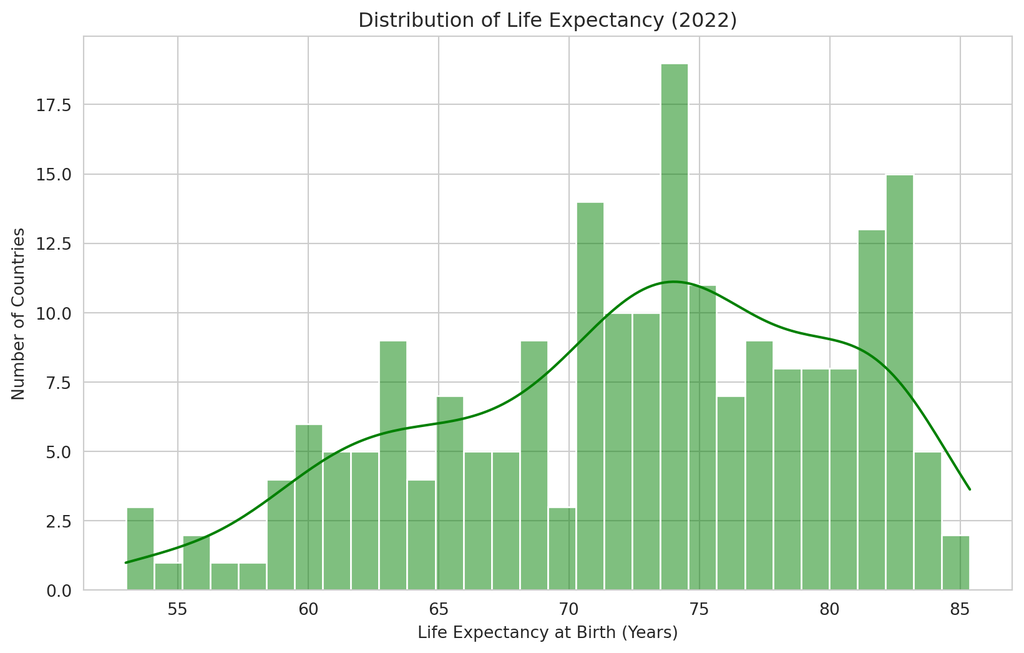

Figure 1: Distribution of Life Expectancy in 2022.

From the summary statistics in **Table 1**, we see that the mean life expectancy of the countries is 72.42, the median is 73.51, and the standard deviation is 7.71. In **Figure 1**, we see a longer and thiner tail of life expectancies on the lower end, and a shorter and thicker tail of life expectancies on the high end. In developmental economics, the Preston Curve tells us that life expectancy does not have a linear relationship to GDP per capita (Preston 1975).

### Inflation analysis:

```python
inf_rate_series = wdi['inflation_rate']
print("Inflation Rate (Annual %):")
print(f"- Mean: {inf_rate_series.mean():.2f}")
print(f"- Median: {inf_rate_series.median():.2f}")
print(f"- Standard Deviation: {inf_rate_series.std():.2f}")
```

```
Inflation Rate (Annual %):
- Mean: 12.49
- Median: 7.97
- Standard Deviation: 19.68
```

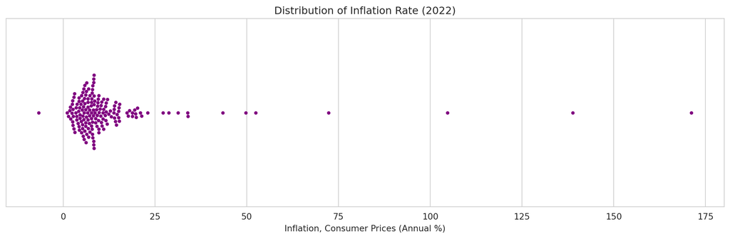

Figure 2: A swarm plot of 2022 inflation rates, showing the precise location of each country.

### GDP Per Capita analysis:

```python
gdp_series = wdi['gdp_per_capita']
print("GDP Per Capita (USD):")
print(f"- Mean: ${gdp_series.mean():,.2f}")
print(f"- Median: ${gdp_series.median():,.2f}")
print(f"- Standard Deviation: ${gdp_series.std():,.2f}")
```

```
GDP Per Capita (USD):
- Mean: $20,345.71
- Median: $7,587.59
- Standard Deviation: $31,308.94
```

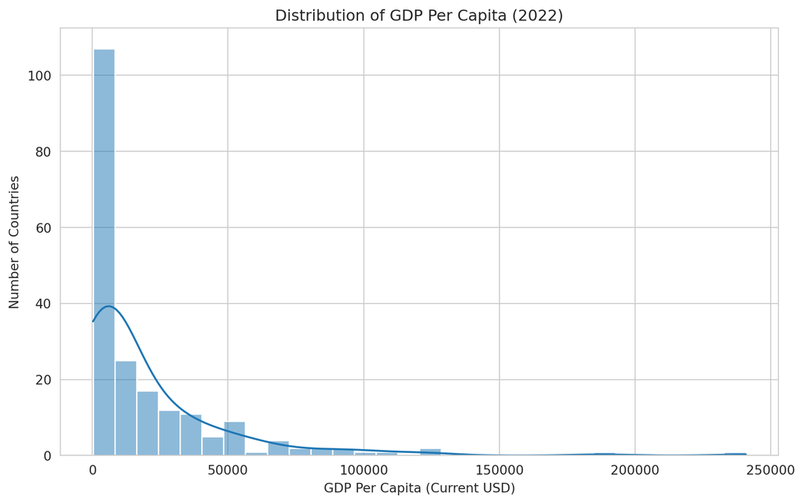

Figure 3: Distribution of GDP Per Capita in 2022.

From the summary statistics in **Table 1**, we see that the mean GDP per capita of the countries is $20,345.71, the median is $7,587.59, and standard deviation is $31,308.94. In **Figure 3**, we observe that the GDP per capita of the countries in the data set follow a power law distributions. Most of the countries are clustered in the low GDP per capita buckets, a small number a clustered in middle GDP per capita buckets, and there are a tiny number of outliers with very high GDP per capita.

Table 1: Summary Statistics for Key Indicators (2022).

```
|                    |   GDP per Capita ($) |   Life Expectancy (Years) |   Inflation Rate (%) |
|:-------------------|---------------------:|--------------------------:|---------------------:|
| Mean               |            20,345.71 |                     72.42 |                12.49 |
| Median             |             7,587.59 |                     73.51 |                 7.97 |
| Standard Deviation |            31,308.94 |                      7.71 |                19.68 |
```

## References

Barro, Robert J. 1996. “Inflation and Economic Growth.” *Federal Reserve Bank of St. Louis Review* 78 (3): 153–69. https://doi.org/10.20955/r.78.153-69.

Preston, Samuel H. 1975. “The Changing Relation Between Mortality and Level of Economic Development.” *Population Studies* 29 (2): 231–48.

The World Bank. 2022. “World Development Indicators.” The World Bank Group. https://databank.worldbank.org/source/world-development-indicators.